# Species metadata description

# Biodiversity mapping

The following pdf gives a description of the data used in the pipeline run that corresponds to the folder this document resides in. It should be used as a guide for anyone who wants to know more about the data used in the corresponding outputs (maps and datasets) and/or would like to replicate the data.

We begin with basic information about the pipeline run.

| Characteristic | Value |
| --- | --- |
| Date | 2023-08-01 |
| Taxa | vascularPlants |
| Taxa code | 7707728 |
| Region type | county |
| Region code | 50 |
| Total species | 8 |
| Total datasets used | 7 |

In addition to the above, data was downloaded with a maximum uncertainty regarding coordinates of 500 metres.

The following shows total number of observations per taxa and per dataset from the initial download from GBIF and ANO. Note that only the top 10 datasets are shown. A full list of observations per dataset per taxa as well as observations per species can be found in the appendices.

| taxa | Observations |
| --- | --- |
| vascularPlants | 16364 |

| datasetName | Observations |
| --- | --- |
| Vascular plant field notes, NTNU University Museum | 9232 |
| Norwegian Species Observation Service | 5118 |
| ANOData | 1491 |
| iNaturalist Research-grade Observations | 273 |
| Vascular plant herbarium TRH, NTNU University Museum | 139 |
| Overvåking av semi-naturlig eng (ASO) | 104 |
| Artportalen (Swedish Species Observation System) | 7 |

The following gives spatial density for observations across the surveyed region by taxa.

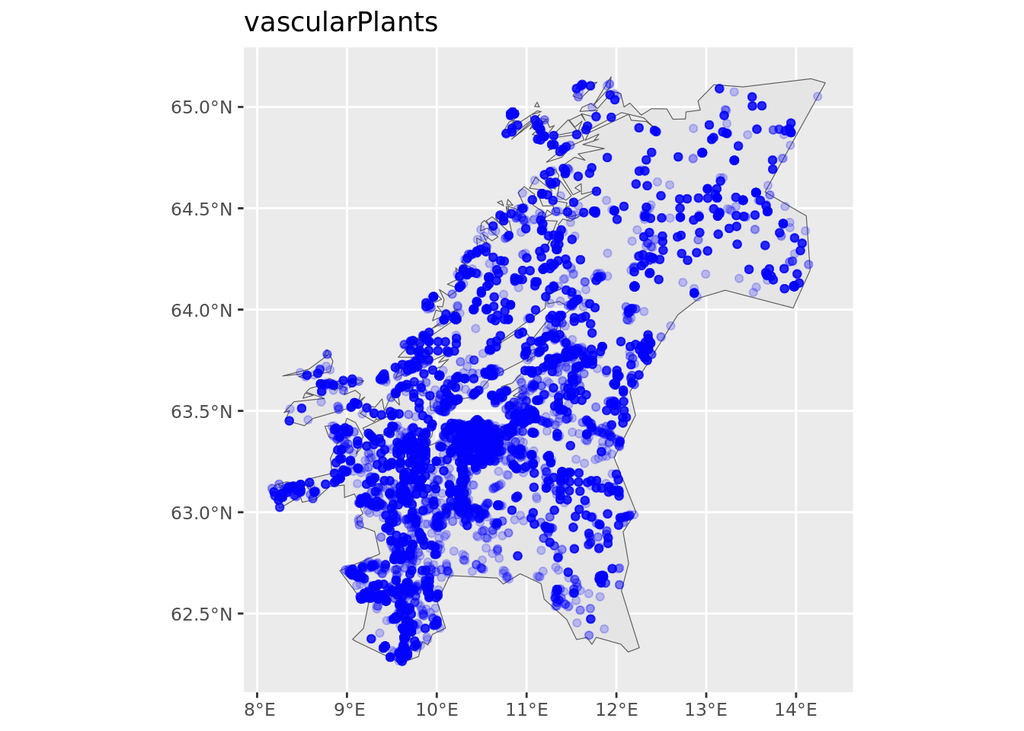

## Appendices

### Appendix 1

The tables below give further information on the observations used for our pipeline run.

Total numbers of observations used in pipeline run for each species.

| simpleScientificName | Observations |
| --- | --- |
| Geranium_sylvaticum | 2385 |
| Juniperus_communis | 2221 |
| Betula_pubescens | 2184 |
| Saxifraga_aizoides | 2129 |
| Ulmus_glabra | 2084 |
| Agrostis_capillaris | 1899 |
| Vicia_sepium | 1814 |
| Fraxinus_excelsior | 1648 |

Total numbers of observations used in pipeline run for each dataset by taxa.

| taxa | datasetName | Observations |
| --- | --- | --- |
| vascularPlants | Vascular plant field notes, NTNU University Museum | 9232 |
| vascularPlants | Norwegian Species Observation Service | 5118 |
| vascularPlants | ANOData | 1491 |
| vascularPlants | iNaturalist Research-grade Observations | 273 |
| vascularPlants | Vascular plant herbarium TRH, NTNU University Museum | 139 |
| vascularPlants | Overvåking av semi-naturlig eng (ASO) | 104 |
| vascularPlants | Artportalen (Swedish Species Observation System) | 7 |